# data.table in R

20. Januar 2016

## Über mich

- Statistik Student an der Ludwig-Maximilians-Universität München
- Aktuell Masterarbeit am IMBE in Erlangen
- Meetups:
  - [Munich datageeks](http://munich-datageeks.de/)
  - [Applied R Munich](http://lmu-applied-r.github.io/)
- Slides unter:
  - https://github.com/ja-thomas/data.table_talk

*statistics*, *machine learning*, *R*, *boosting*, *model selection*, *optimization*, *Linux*, *ensemble methods*, *parallel programming*, *data mining*, *support vector machines*, *visualization*, *python*, *SQL*, *predictive modelling*, …

## *data.table*

- R Paket von M Dowle, A Srinivasan, T Short, S Lianoglou, …
- Aktuell Version 1.9.6
- Beschreibung:

  Fast aggregation of large data (e.g. 100GB in RAM), fast ordered joins, fast add/modify/delete of columns by group using no copies at all, list columns and a fast file reader (fread). Offers a natural and flexible syntax, for faster development.

```r
install.packages("data.table")
```

```r
library(data.table)
```

## Was ist denn überhaupt ein *data.frame*?

Kann man sich sich vorstellen wie:

- Eine `matrix()` die unterschiedliche Typen haben darf (integer, character, factors, etc.)
- Eine `list()` von Vektoren die alle die gleiche Länge haben.

```r
data.frame(a = c(1,2,3,5), b = c("A", "B", "C", "D"))
```

```
##   a b
## 1 1 A
## 2 2 B
## 3 3 C
## 4 5 D
```

## Und was kann jetzt ein *data.table*?

- Effizientere Schreibweise:
  - Weniger Funktionsaufrufe
  - Weniger Wiederholung von Variablen Namen
- Schnellere Berechnung:
  - Schnelle Aggregationen
  - Updates über Referenzierung
- Geringerer Speicherbedarf
- Schnelles einlesen von Datensätzen

Und vielleicht das wichtigste:

```
Vollständig kompatibel mit jeder Operation die data.frames verwendet.
```

## *data.frame*, *data.table* und *SQL*

| Auswahl | *data.frame* | *data.table* | *SQL* |
| --- | --- | --- | --- |
| Zeilen | `DF[i, ]` | `DT[i]` | *WHERE* |
| Spalten | `DF[ , j]` | `DT[, .(j)]` | *SELECT* |
| Gruppierung | *???* | `DT[by = ...]` | *GROUP BY* |

## *data.tables* allgemeine Form

```r
DT[i, j, by]
```

```
Nehme nur die Zeilen i, dann berechne j und gruppiere nach by.
```

Moment mal, warum *berechne j* ? Wir wollen doch nur Spalten auswählen!

```r
data("mtcars")
mtcarsDT <- data.table(mtcars)
mtcarsDT[mpg > 20,
         .(AvgHP = mean(hp),
           "MinWT(kg)" = min(wt*453.6)),
         by = .(cyl, under5gears = gear < 5)]
```

Implizite Berechnung neuer Variablen, später mehr dazu

## Beispieldatensatz: *mtcars*

Motor Trend Car Road Tests

```r
dim(mtcars)
```

```
## [1] 32 11
```

```r
ls.str(mtcars)
```

```
## am :  num [1:32] 1 1 1 0 0 0 0 0 0 0 ...
## carb :  num [1:32] 4 4 1 1 2 1 4 2 2 4 ...
## cyl :  num [1:32] 6 6 4 6 8 6 8 4 4 6 ...
## disp :  num [1:32] 160 160 108 258 360 ...
## drat :  num [1:32] 3.9 3.9 3.85 3.08 3.15 2.76 3.21 3.69 3.92 3.92 ...
## gear :  num [1:32] 4 4 4 3 3 3 3 4 4 4 ...
## hp :  num [1:32] 110 110 93 110 175 105 245 62 95 123 ...
## mpg :  num [1:32] 21 21 22.8 21.4 18.7 18.1 14.3 24.4 22.8 19.2 ...
## qsec :  num [1:32] 16.5 17 18.6 19.4 17 ...
## vs :  num [1:32] 0 0 1 1 0 1 0 1 1 1 ...
## wt :  num [1:32] 2.62 2.88 2.32 3.21 3.44 ...
```

## *j*: mehr als nur Spalten auswählen

Wenn mehr als eine Spalte ausgewählt wird, muss `.()` verwendet werden.

```r
mtcarsDT[, .(mpg, cyl)]
```

Durch diese Schreibweise können direkt Berechnungen durchgeführt werden:

```r
mtcarsDT[, .(mean_mpg = mean(mpg),
             min_mpg = min(mpg),
             max_mpg = max(mpg))]
```

```
##    mean_mpg min_mpg max_mpg
## 1: 20.09062    10.4    33.9
```

## *j*: mehr als nur Spalten auswählen

*Achtung*: Auswahl über Spaltennummern funktioniert nicht!

```r
mtcarsDT[, .(1)] # identisch zu mtcarsDT[, 1]
```

```
##    V1
## 1:  1
```

`data.frame` Verhalten kann mit `with = FALSE` erzwungen werden. (Ist aber nicht zu empfehlen!)

## *j*: mehr als nur Spalten auswählen

*Nice to know*: Es kann (fast) jede Funktion in *j* verwendet werden

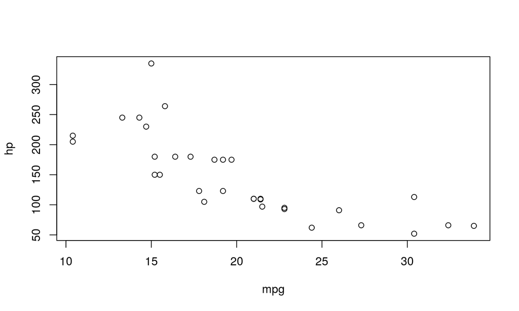

```
## Empty data.table (0 rows) of 1 col: V1
```

```r
mtcarsDT[, .(plot(mpg, hp))]
```

## Gruppierungen mit *by*

Wieder mit `.()` verwenden.

```r
mtcarsDT[, .(mean_mpg = mean(mpg)), by = .(cyl)]
```

```
##    cyl mean_mpg
## 1:   6 19.74286
## 2:   4 26.66364
## 3:   8 15.10000
```

Auch in *by* können wieder Funktionen verwendet werden:

```r
mtcarsDT[, .(mean_mpg = mean(mpg)),
             by = .(tons = round(wt * 0.4536))]
```

```
##    tons mean_mpg
## 1:    1 24.51250
## 2:    2 15.66875
```

## Gruppierungen mit *by*

*Nice to know*: Als shortcut für `nrow()` kann einfach `.N` verwndet werden

```r
mtcarsDT[, .(Anzahl = .N),
         by = .(cyl, am)]
```

```
##    cyl am Anzahl
## 1:   6  1      3
## 2:   4  1      8
## 3:   6  0      4
## 4:   8  0     12
## 5:   4  0      3
## 6:   8  1      2
```

## Und jetzt alles auf einmal

```r
mtcarsDT[mpg > 20,
         .(AvgHP = mean(hp),
           "MinWT(kg)" = min(wt*453.6)),
         by = .(cyl, under5gears = gear < 5)]
```

```
##    cyl under5gears     AvgHP MinWT(kg)
## 1:   6        TRUE 110.00000 1188.4320
## 2:   4        TRUE  78.33333  732.5640
## 3:   4       FALSE 102.00000  686.2968
```

## Schnelleres suchen und finden mit *keys*

- *keys* sind ein (oder mehrere) Spalten im Datensatz
- Der Datensatz wird immer (aufsteigend) nach den *keys* sortiert
- *keys* müssen *nicht* eindeutig sein

```r
setkeyv(mtcarsDT, "cyl")
head(mtcarsDT)
```

```
##     mpg cyl  disp hp drat    wt  qsec vs am gear carb
## 1: 22.8   4 108.0 93 3.85 2.320 18.61  1  1    4    1
## 2: 24.4   4 146.7 62 3.69 3.190 20.00  1  0    4    2
## 3: 22.8   4 140.8 95 3.92 3.150 22.90  1  0    4    2
## 4: 32.4   4  78.7 66 4.08 2.200 19.47  1  1    4    1
## 5: 30.4   4  75.7 52 4.93 1.615 18.52  1  1    4    2
## 6: 33.9   4  71.1 65 4.22 1.835 19.90  1  1    4    1
```

## Schnelleres suchen und finden mit *keys*

Mit dem Schlüssel kann direkt gefiltert werden:

```r
mtcarsDT[.(6)]
```

```
##     mpg cyl  disp  hp drat    wt  qsec vs am gear carb
## 1: 21.0   6 160.0 110 3.90 2.620 16.46  0  1    4    4
## 2: 21.0   6 160.0 110 3.90 2.875 17.02  0  1    4    4
## 3: 21.4   6 258.0 110 3.08 3.215 19.44  1  0    3    1
## 4: 18.1   6 225.0 105 2.76 3.460 20.22  1  0    3    1
## 5: 19.2   6 167.6 123 3.92 3.440 18.30  1  0    4    4
## 6: 17.8   6 167.6 123 3.92 3.440 18.90  1  0    4    4
## 7: 19.7   6 145.0 175 3.62 2.770 15.50  0  1    5    6
```

## Schnelleres suchen und finden mit *keys*

Wenn mehrere Schlüssel gesetzt werden, kann man Anfragen kombinieren:

```r
setkeyv(mtcarsDT, c("cyl", "carb"))
mtcarsDT[.(6, 4)]
```

```
##     mpg cyl  disp  hp drat    wt  qsec vs am gear carb
## 1: 21.0   6 160.0 110 3.90 2.620 16.46  0  1    4    4
## 2: 21.0   6 160.0 110 3.90 2.875 17.02  0  1    4    4
## 3: 19.2   6 167.6 123 3.92 3.440 18.30  1  0    4    4
## 4: 17.8   6 167.6 123 3.92 3.440 18.90  1  0    4    4
```

## Variablen definieren `:=`

Variablen können direkt in *j* hinzugefügt, geändert oder gelöscht werden:

```r
#neue Variable - Gewicht in Kilo
mtcarsDT[, wt_kg := wt * 0.4536]

#geänderte Variable - Gewicht mit 2 Komma Stellen
mtcarsDT[, wt_kg := round(wt_kg, 2)]

#gelöschte Variable - Gewicht in Kilo wieder löschen
mtcarsDT[, wt_kg := NULL]
```

## Variablen definieren `:=`

*Achtung*: `:=` modifiziert *by reference*, d.h.:

```r
mtcarsDT[, wt_kg := wt * 45.36]
```

Verändert den Datensatz `mtcarsDT`!

Eine Neue Zuweisung über `<-` reicht *nicht* aus, es muss `copy()` verwendet werden.

## Variablen definieren `:=`

Stolperfalle:

```r
ncol(mtcarsDT)
```

```
## [1] 12
```

```r
mtcarsDT2 <- mtcarsDT
mtcarsDT2[, wt_kg := NULL]
ncol(mtcarsDT)
```

```
## [1] 11
```

*wt_kg* ist auch in `mtcarsDT` verschwunden!

## Variablen definieren `:=`

```r
mtcarsDT[, wt_kg := wt * 45.36]
ncol(mtcarsDT)
```

```
## [1] 12
```

```r
mtcarsDT2 <- copy(mtcarsDT)
mtcarsDT2[, wt_kg := NULL]
ncol(mtcarsDT)
```

```
## [1] 12
```

Dafür benötigt ein referenzierter Datensatz aber auch *keinen* zusätzlichen Speicher!

## Schnelles einlesen mit `fread`

*data.table* liefert die Funktion `fread` um große Datensätze (Tabellen) extrem effizient einzulesen.

Hier keine Benchmarks, aber für Interessierte:

http://stackoverflow.com/questions/1727772/quickly-reading-very-large-tables-as-dataframes-in-r http://www.biostat.jhsph.edu/~rpeng/docs/R-large-tables.html https://stat.ethz.ch/pipermail/r-help/2007-August/138315.html http://www.cerebralmastication.com/2009/11/loading-big-data-into-r/ http://stackoverflow.com/questions/9061736/faster-than-scan-with-rcpp http://stackoverflow.com/questions/415515/how-can-i-read-and-manipulate-csv-file-data-in-c http://stackoverflow.com/questions/9352887/strategies-for-reading-in-csv-files-in-pieces http://stackoverflow.com/questions/11782084/reading-in-large-text-files-in-r http://stackoverflow.com/questions/45972/mmap-vs-reading-blocks http://stackoverflow.com/questions/258091/when-should-i-use-mmap-for-file-access http://stackoverflow.com/a/9818473/403310 http://stackoverflow.com/questions/9608950/reading-huge-files-using-memory-mapped-files …

## Exkurs: Transformieren mit `reshape2`

`reshape2` ist ein Paket zum effizienten umformen von Daten.

Die zwei wichtigsten Funktionen für uns sind `melt` und `dcast`

*wide* -> *long* : `melt`

*long* -> *wide* : `dcast`

## `reshape2`: `melt`

```r
wd <- data.frame(person = 1:3,
                 gewicht = round(runif(3, min = 60, max = 90)),
                 groesse = round(runif(3, min = 160, max = 190)))
wd
```

```
##   person gewicht groesse
## 1      1      69     167
## 2      2      82     173
## 3      3      77     187
```

`wd` ist im *wide* Format!

## `reshape2`: `melt`

```r
wd_long <- melt(wd, id = "person")
wd_long
```

```
##   person variable value
## 1      1  gewicht    69
## 2      2  gewicht    82
## 3      3  gewicht    77
## 4      1  groesse   167
## 5      2  groesse   173
## 6      3  groesse   187
```

Die Spalte *variable* kann auch mit `variable.name =` direkt anders benannt werden.

## `reshape2`: `dcast`

```r
wd_wide <- dcast(wd_long, person ~ variable)
wd_wide
```

```
##   person gewicht groesse
## 1      1      69     167
## 2      2      82     173
## 3      3      77     187
```

```r
all.equal(wd_wide, wd)
```

```
## [1] TRUE
```

Sowohl `melt` als auch `dcast` können mit mehreren Faktoren umgehen.

## `reshape2` für *data.table*

Was sollte jetzt dieser Exkurs?

`melt` und `dcast` sind ebenfalls in *data.table* implementiert!

*Achtung*: `reshape` aus *base* R liefert immer einen *data.frame* zurück!

## JOINing *data.tables*

| JOIN | *data.frame* | *data.table* |
| --- | --- | --- |
| INNER | `merge(X, Y, all = FALSE)` | `X[Y, nomatch = 0]` |
| LEFT OUTER | `merge(X, Y, all.x = TRUE)` | `Y[X]` |
| RIGHT OUTER | `merge(X, Y, all.y = TRUE)` | `X[Y]` |
| FULL OUTER | `merge(X, Y, all = TRUE)` | - |

`merge()` Funktioniert auch für *data.table*

(nötig z.B. bei FULL OUTER JOIN)

## Das wichtigste zum Schluss

```r
data.table(x = rnorm(1000), y = rnorm(1000))
```

```
##                 x            y
##    1:  0.46415868  0.360111003
##    2:  0.54989832 -0.839365502
##    3: -0.06125131 -1.502301744
##    4: -1.14067795  2.276631173
##    5: -0.87681387  0.794319945
##   ---
##  996:  0.71039690  1.124448314
##  997:  0.58281744 -0.670967891
##  998:  1.85128242 -0.772898521
##  999:  0.05066844  0.993159962
## 1000:  0.58248588  0.005554499
```

Überladene `print` Funktion für große Datensätze!

## Zusammenfassung

- Zeilen filtern in *i*
  - Für schnelles filtern *key* setzen
- In *j* können berechnungen ausgeführt werden
  - Immer in `.()` einpacken
  - Standard *data.frame* Syntax funktioniert nur mit `with = FALSE`
- Gruppieren mit *by*
  - Wieder in `.()` einpacken
  - Auch hier können Funktionen ausgewertet werden
- Variablen mit `:=` definieren/ändern/löschen
  - Achtung vor *call by reference*
- `melt` und `dcast` statt `reshape` verwenden
- JOINS können über kurze Syntax geschrieben werden

## Resourcen

- https://cran.r-project.org/web/packages/data.table/
- Vignetten: [1](https://cran.r-project.org/web/packages/data.table/vignettes/datatable-intro-vignette.html), [2](https://cran.r-project.org/web/packages/data.table/vignettes/datatable-keys-fast-subset.html), [3](https://cran.r-project.org/web/packages/data.table/vignettes/datatable-reference-semantics.html), [4](https://cran.r-project.org/web/packages/data.table/vignettes/datatable-reshape.html)
- [Cheat Sheet](https://s3.amazonaws.com/assets.datacamp.com/img/blog/data+table+cheat+sheet.pdf)
- Video Kurs auf https://www.datacamp.com/
  - Nur erste Einheit kostenlos :(
  - Beispiele aus diesem Talk sind von hier!
- Talk von Matt Dowle auf der UseR2014
  - [klick](http://user2014.stat.ucla.edu/files/tutorial_Matt.pdf)

## Alternativen

- `dplyr`: Verwendet chaining Syntax `%>%`
  - https://github.com/lmu-applied-r/2015-dplyr (von Applied R München)
- SQL oder noSQL Datenbank (extern)
- Kommerzielle R Versionen: Revolution R / Microsoft R
- …
- Kaffee trinken
- …
- Vorschläge?

## Fragen?

Vielen Dank für Eure Aufmerksamkeit  
Fragen? Meinungen? Anregungen?